# Donor Profile: United Arab Emirates (Government of)

## Focus Portfolio

The United Arab Emirates’ portfolio highlights a concentrated yet impactful funding landscape with total contributions reaching up to $15 million. Despite a relatively small dataset of four key funding streams, the mean contribution of approximately $4.6 million signifies a strong investment base that can be leveraged to expand regional refugee programs. Notably, the uneven distribution—ranging from $95,000 to $15 million—presents an opportunity to strategically scale mid-level investments which currently represent the 25th to 75th percentile range ($165,000 to $6 million). This variance signals untapped potential for donor collaboration and partnership diversification, essential for enhancing programmatic reach and sustainability. We recommend positioning UAE funding as an impact multiplier, emphasizing its ability to catalyze complementary contributions and innovation in emergency response and resilience-building. Immediate executive action should prioritize allocating resources to engage UAE stakeholders in high-value partnerships, focusing on underfunded regions where proportional increases can produce significant outcomes. Mobilizing these investments now can mitigate risks associated with funding volatility and strengthen accountability mechanisms critical to donor confidence and long-term impact.

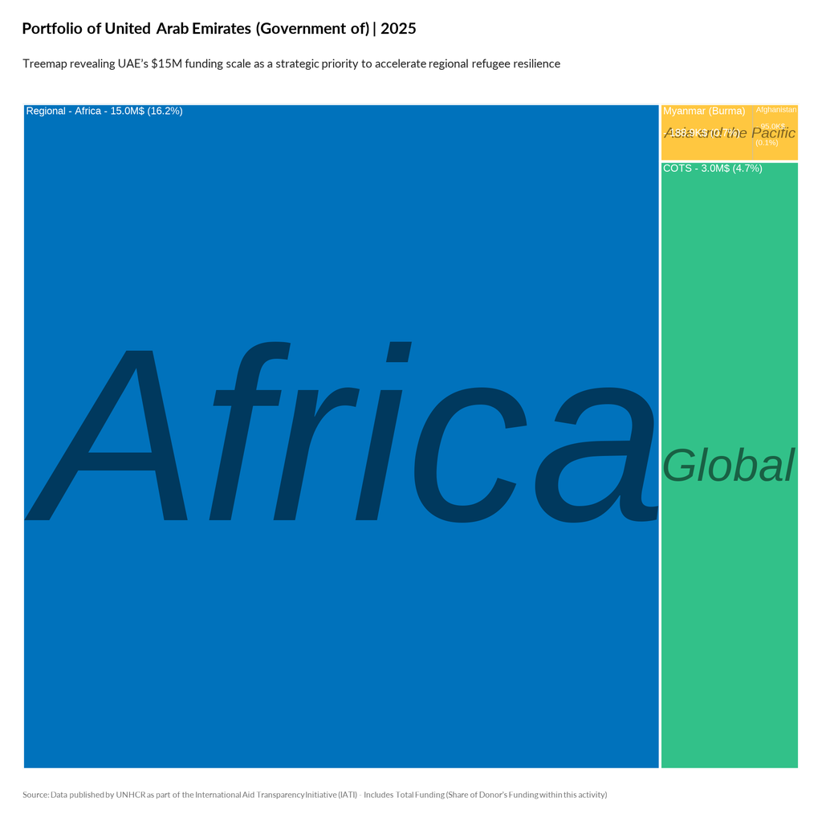

TRUE

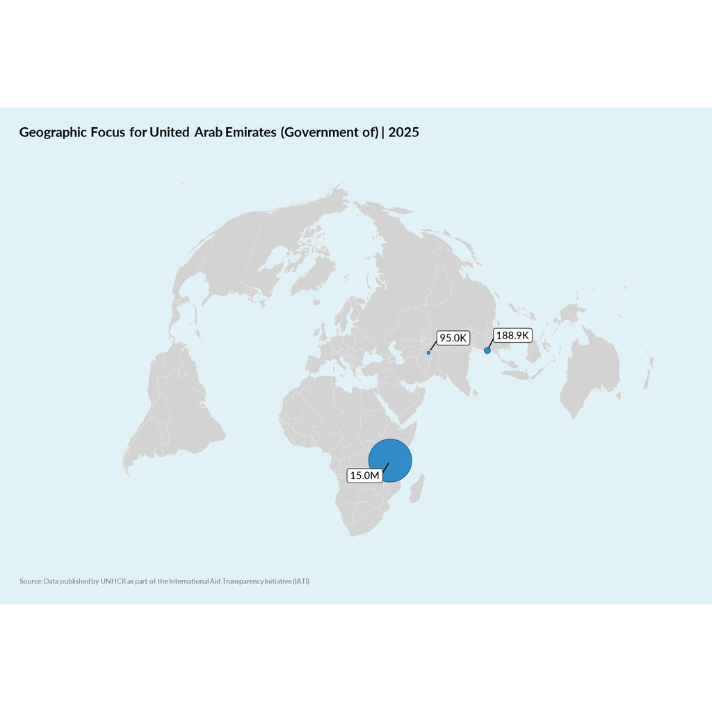

TRUE